# Week 2 exercises

# Second part, using the data & regression analysis

**Step 1: opening the data and exploring**

I opened the data by using the menu, but could have probably used code too. Also I didn’t realize at first you need to specify the data each time you chunk code in rmarkdown? That took a while to figure out…

The learning2014 dataset has 166 observations (no missing values), and 7 variables, as the following shows:

```r
learning2014 <- read.csv("C:\\Users\\Laura\\Documents\\GitHub\\IODS-project\\learning2014", header=TRUE)

dim(learning2014)
```

```
## [1] 166   7
```

```r
names(learning2014)
```

```
## [1] "gender"   "Age"      "Attitude" "deep"     "stra"     "surf"
## [7] "Points"
```

```r
summary(learning2014)
```

```
##  gender       Age           Attitude          deep            stra
##  F:110   Min.   :17.00   Min.   :14.00   Min.   :1.583   Min.   :1.250
##  M: 56   1st Qu.:21.00   1st Qu.:26.00   1st Qu.:3.333   1st Qu.:2.625
##          Median :22.00   Median :32.00   Median :3.667   Median :3.188
##          Mean   :25.51   Mean   :31.43   Mean   :3.680   Mean   :3.121
##          3rd Qu.:27.00   3rd Qu.:37.00   3rd Qu.:4.083   3rd Qu.:3.625
##          Max.   :55.00   Max.   :50.00   Max.   :4.917   Max.   :5.000
##       surf           Points
##  Min.   :1.583   Min.   : 7.00
##  1st Qu.:2.417   1st Qu.:19.00
##  Median :2.833   Median :23.00
##  Mean   :2.787   Mean   :22.72
##  3rd Qu.:3.167   3rd Qu.:27.75
##  Max.   :4.333   Max.   :33.00
```

*Step 2: show a graphical overview of the data and show summaries of the variables in the data*

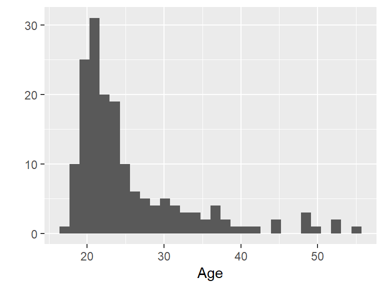

```r
learning2014 <- read.csv("C:\\Users\\Laura\\Documents\\GitHub\\IODS-project\\learning2014", header=TRUE)
library(ggplot2)
qplot(Age,data=learning2014)
```

```r
summary(learning2014$Age)
```

```
##    Min. 1st Qu.  Median    Mean 3rd Qu.    Max.
##   17.00   21.00   22.00   25.51   27.00   55.00
```

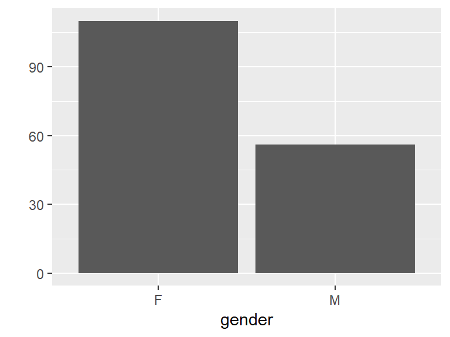

```r
qplot(gender,data=learning2014)
```

```r
summary(learning2014$gender)
```

```
##   F   M
## 110  56
```

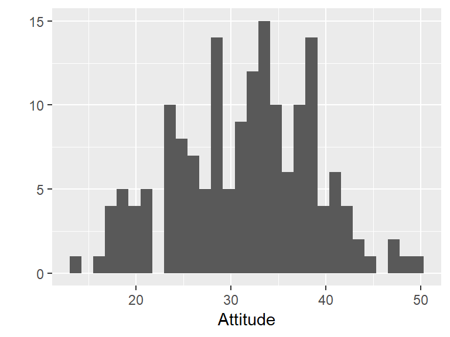

```r
qplot(Attitude,data=learning2014)
```

```r
summary(learning2014$Attitude)
```

```
##    Min. 1st Qu.  Median    Mean 3rd Qu.    Max.
##   14.00   26.00   32.00   31.43   37.00   50.00
```

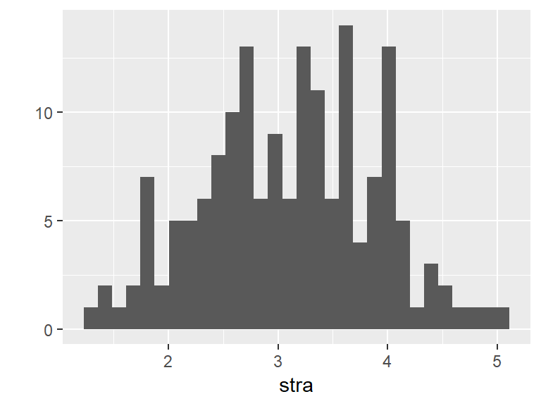

```r
qplot(stra,data=learning2014)
```

```r
summary(learning2014$stra)
```

```
##    Min. 1st Qu.  Median    Mean 3rd Qu.    Max.
##   1.250   2.625   3.188   3.121   3.625   5.000
```

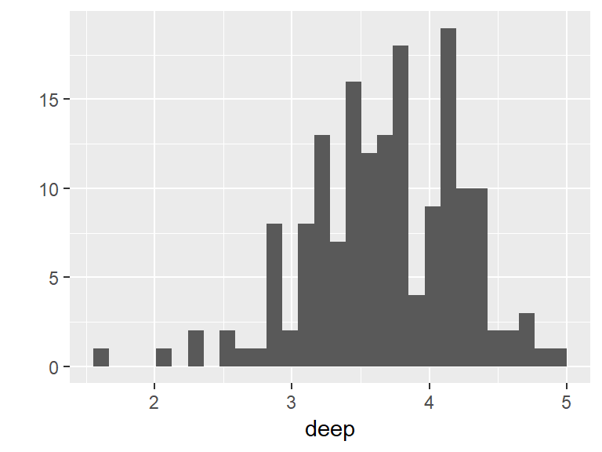

```r
qplot(deep,data=learning2014)
```

```r
summary(learning2014$deep)
```

```
##    Min. 1st Qu.  Median    Mean 3rd Qu.    Max.
##   1.583   3.333   3.667   3.680   4.083   4.917
```

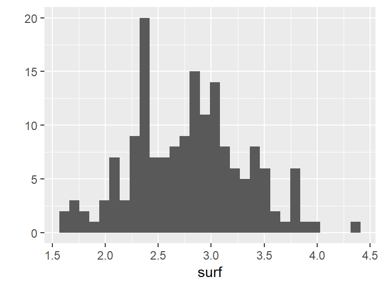

```r
qplot(surf,data=learning2014)
```

```r
summary(learning2014$surf)
```

```
##    Min. 1st Qu.  Median    Mean 3rd Qu.    Max.
##   1.583   2.417   2.833   2.787   3.167   4.333
```

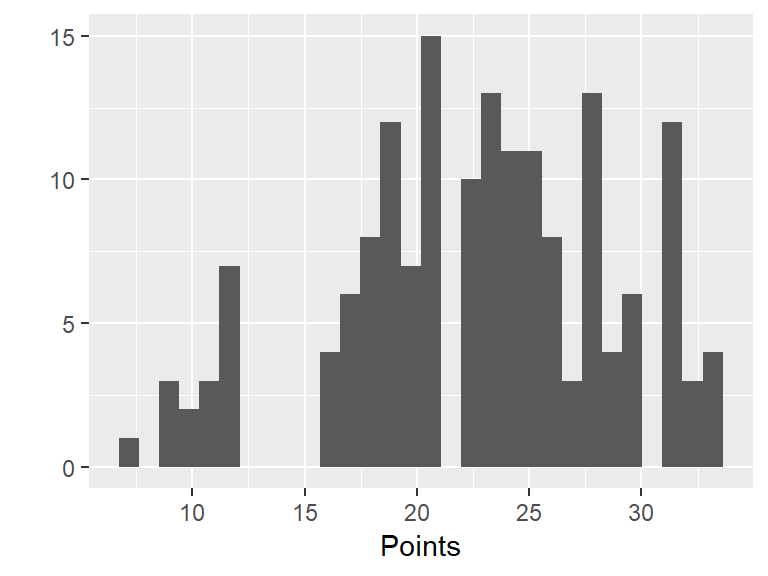

```r
qplot(Points,data=learning2014)
```

```r
summary(learning2014$Points)
```

```
##    Min. 1st Qu.  Median    Mean 3rd Qu.    Max.
##    7.00   19.00   23.00   22.72   27.75   33.00
```

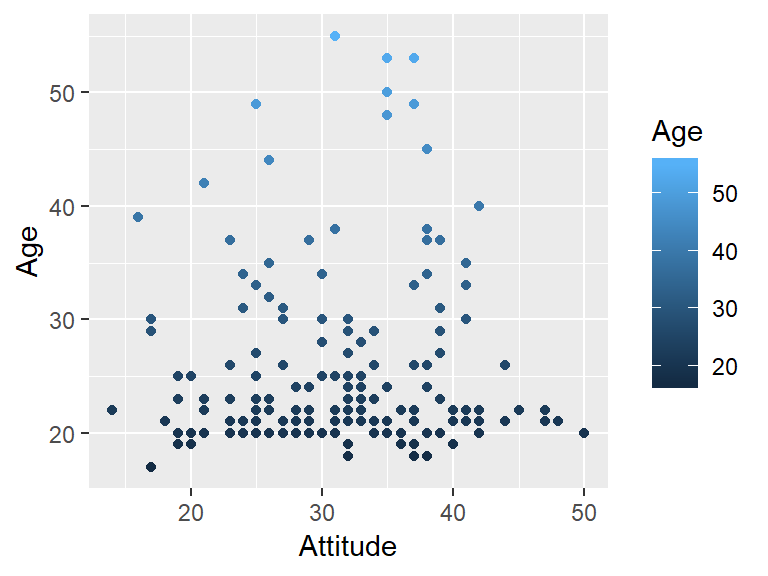

```r
qplot(Attitude,Age,data=learning2014, aes(x=Attitude, y=Age, col=Age))
```

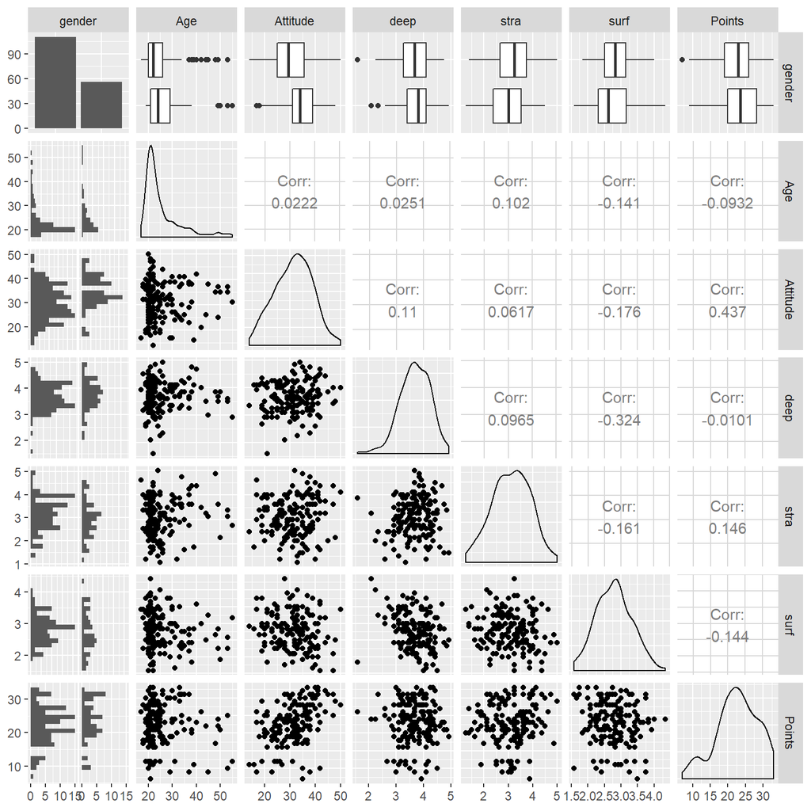

```r
library(GGally)
ggpairs(learning2014, lower = list(combo = wrap("facethist", bins = 20)))
```

*Comments*

It looks like age is quite unequally distributed, with most participants being under the age of 25. There are also considerably more females than males in the data. Attitude, stra, deep and surf at least resemble the normal curve, but there are some obvious gaps with Points. I also wanted to try to plot two variables, Age and Attitudes, just for fun. The scatter plot matrix is cool :D But what can we say from that…The highest correlation seems to be between Points and Attitude, so maybe that’s a preliminary indication that Attitude will be a good predictor for Points. But the other variables are not highly correlated, the seecond highest correlation is 0.32 with deep and surf. There doesn’t seem to be great gender differences either (the only categorical variable)